# Aides Tests

McKayla Witt

May 24, 2017

# Instructions

Three new preventative aides drugs were tested in clinical trials in 2015. The trial designs were modeled after the famous RV_144 Aides Trials in Tailand in 2009. Our reasearch question: Does sex of the participant seem to be a factor for any of the drugs?

# South Carolina

We will subset the data by sex to see if the drug is sex specific.

## AIDs Results (Male)

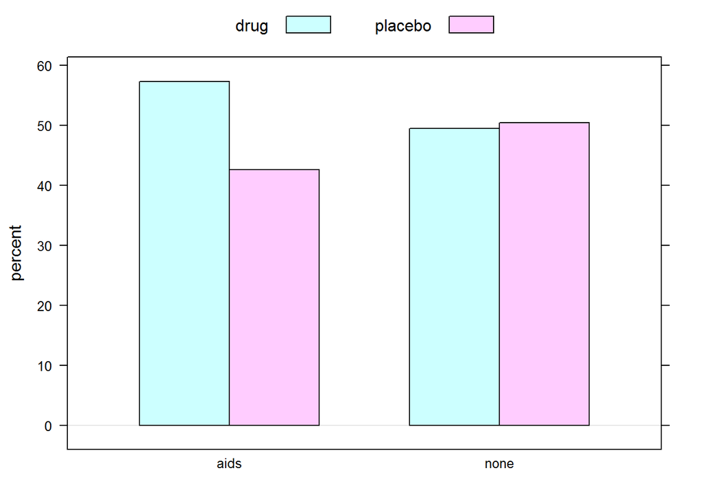

```r
ScarolinaM <- filter(Scarolina, sex=="M")
barchartGC(~infected + group, data = ScarolinaM, type="percent")
```

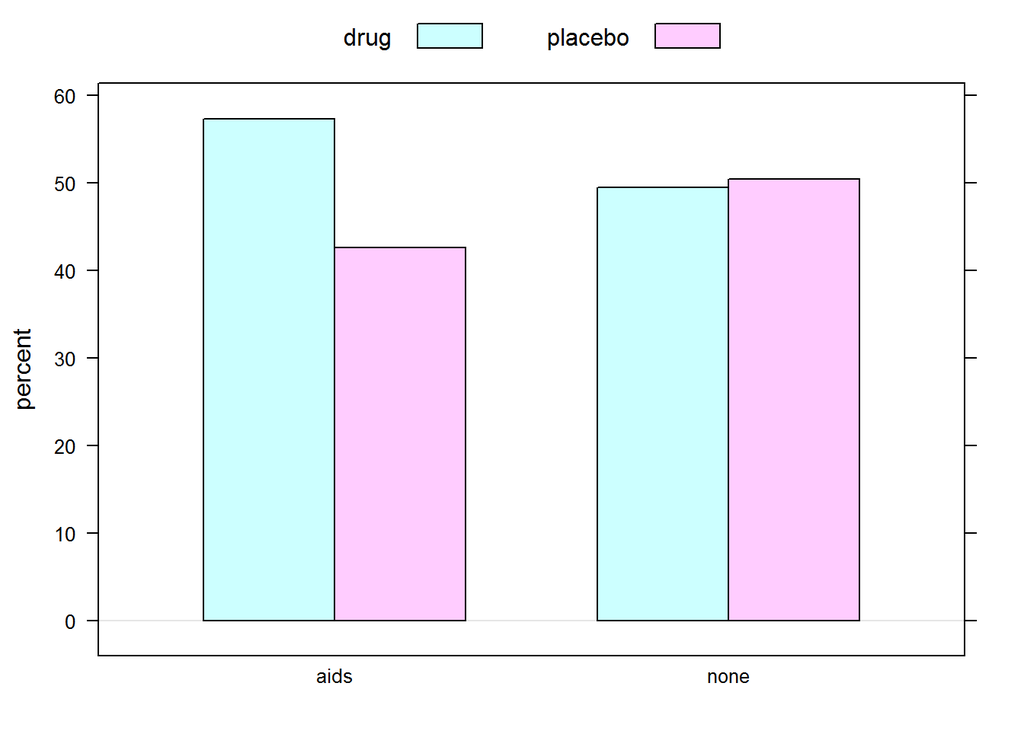

```r
ScarolinaF <- filter(Scarolina, sex=="M")
barchartGC(~infected + group, data = ScarolinaF, type="percent")
```

## AIDs Results (Both)

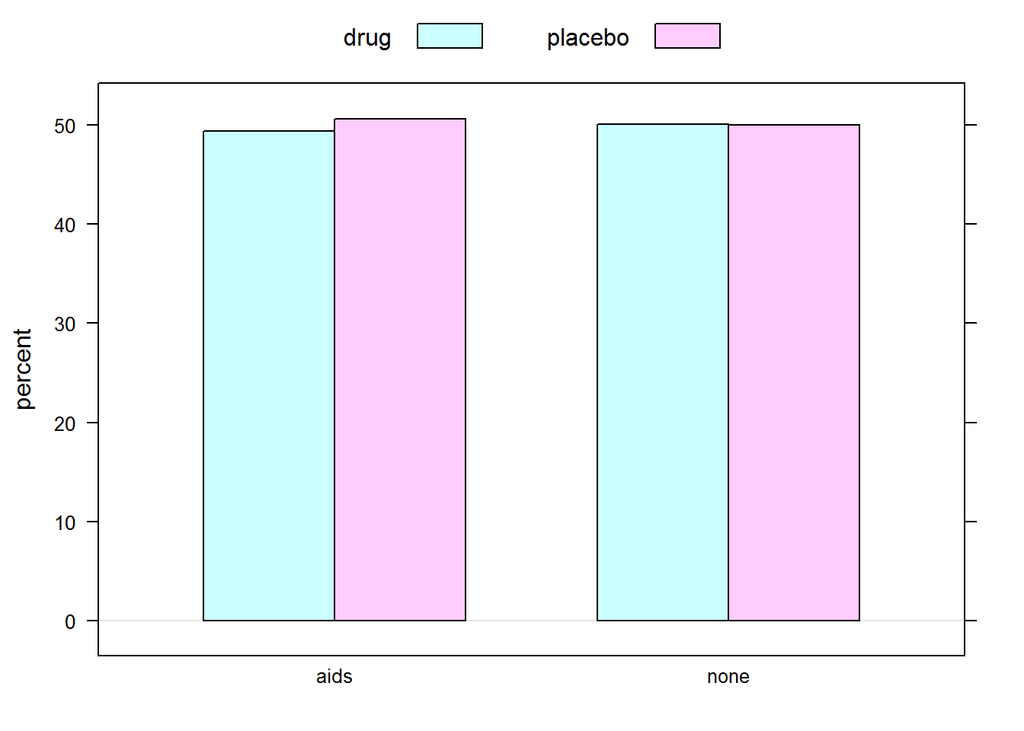

```r
barchartGC(~infected + group, data=Scarolina, type = "percent")
```

Given the barchart, those who conteracted AIDs and were given the placebo was only slightly more (i.e the difference of about 2%) than those who contracted AIDs and were given the drug.

# Central Africa

We will subset the data by sex to see if the drug is sex specific.

## AIDs Results (Male)

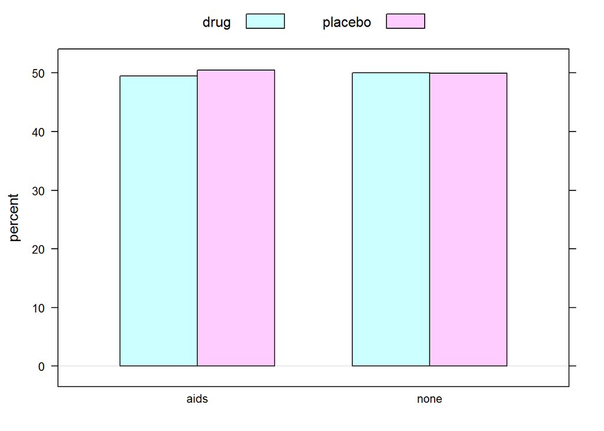

```r
CentralAfricaM <- filter(cenAfrica, sex=="M")
barchartGC(~infected + group, data = CentralAfricaM, type="percent")
```

Given the barchart, it seems more males who recieved the palcebo aquired AIDs (around 50%) than males who recieved the drug (around 49%).

## AIDs Results (Females)

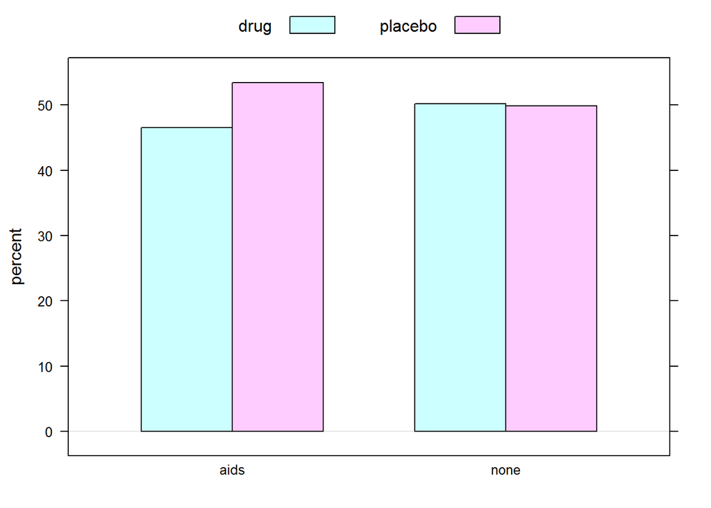

```r
CentralAfricaF <- filter(cenAfrica, sex=="F")
barchartGC(~infected + group, data = CentralAfricaF, type="percent")
```

Given the Barchart, it seems more females who recieved the placebo aquired AIDs (around 55%) than females who recieved the drug (around 45%).

## AIDs Results (Both)

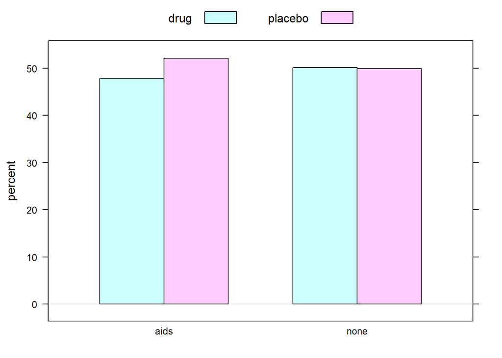

```r
barchartGC(~infected + group, data=cenAfrica, type = "percent")
```

Given the barchart, those who conteracted AIDs and were given the placebo (around 52%) was more than those who contracted AIDs and were given the drug (around 46%).

# Korea

We will subset the data by sex to see if the drug is sex specific.

## AIDs Results (Male)

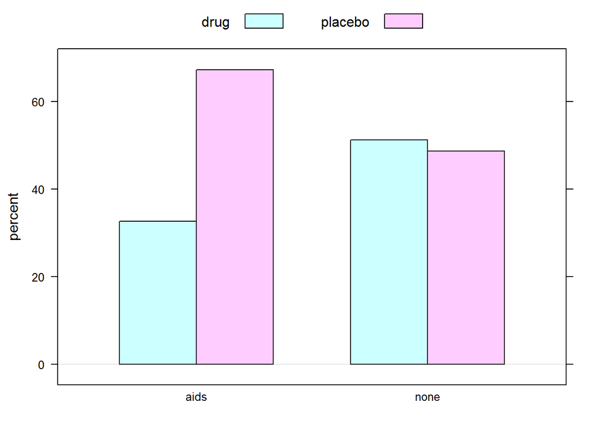

```r
KoreaM <- filter(korea, sex=="M")
barchartGC(~infected + group, data = KoreaM, type="percent")
```

Given the barchart, it seems more males who recieved the palcebo aquired AIDs (over 60%) than males who recieved the drug (around 30%).

## AIDs Results (Females)

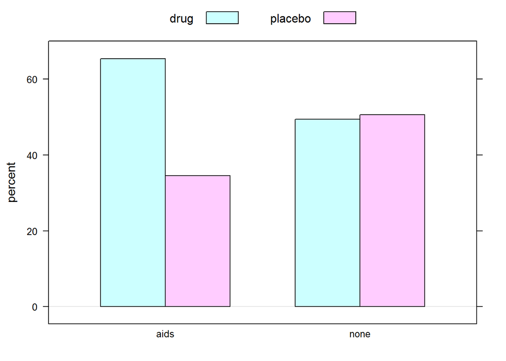

```r
KoreaF <- filter(korea, sex=="F")
barchartGC(~infected + group, data = KoreaF, type="percent")
```

Given the Barchart, it seems more females who recieved the drug aquired AIDs (over 60%) than females who recieved the placebo (under 40%).

## AIDs Results (Both)

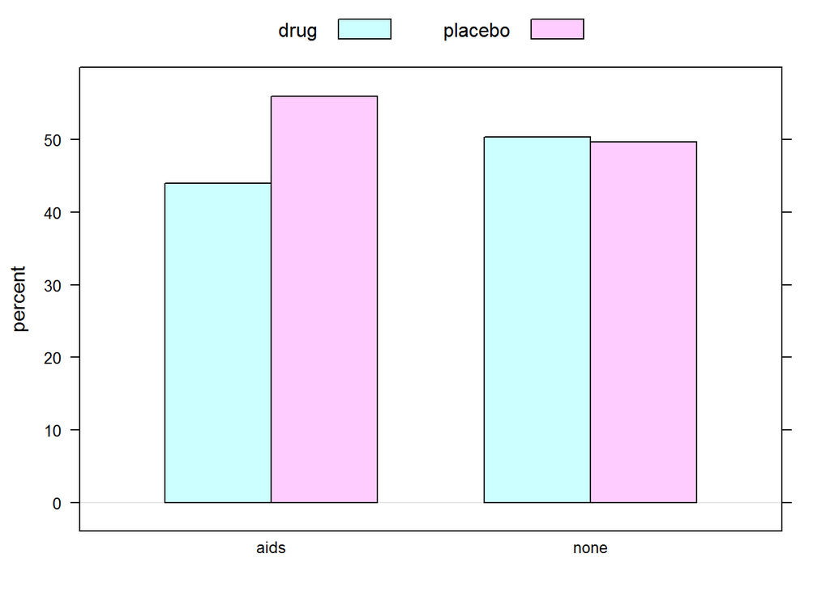

```r
barchartGC(~infected + group, data=korea, type = "percent")
```

Given the barchart, the percentage of poeple who conteracted AIDs and were given the placebo (over 50%) were greater than those who contracted AIDs and were given the drug (around 44%).

# Discussion On Graphical Analysis

# South Carolina

## Males

```r
ScarolinaM_Table <- xtabs(~infected + group, data = ScarolinaM)
rowPerc(ScarolinaM_Table)
```

```
##         group
## infected   drug placebo  Total
##     aids  57.35   42.65 100.00
##     none  49.52   50.48 100.00
```

More males (57.35%) that were infected with aids recieved the actual drug, than males who recieved the placebo.

```r
ScarolinaF_Table <- xtabs(~infected + group, data = ScarolinaF)
rowPerc(ScarolinaF_Table)
```

```
##         group
## infected   drug placebo  Total
##     aids  57.35   42.65 100.00
##     none  49.52   50.48 100.00
```

## Both

```r
Scarolina_Table <- xtabs(~infected + group, data = Scarolina)
rowPerc(Scarolina_Table)
```

```
##         group
## infected   drug placebo  Total
##     aids  49.37   50.63 100.00
##     none  50.04   49.96 100.00
```

Overall 50.04% of those who did not contracted AIDs where given the real drug, while 49.37% of those who caught AIDs where given the drug.

# Central Africa

## Males

```r
CentralAfricaM_Table <- xtabs(~infected + group, data = CentralAfricaM)
rowPerc(CentralAfricaM_Table)
```

```
##         group
## infected   drug placebo  Total
##     aids  49.47   50.53 100.00
##     none  50.02   49.98 100.00
```

More males (50.53%) that were infected with aids recieved the placebo, than males who recieved the drug (49.47%).

## Females

```r
CentralAfricaF_Table <- xtabs(~infected + group, data = CentralAfricaF)
rowPerc(CentralAfricaF_Table)
```

```
##         group
## infected   drug placebo  Total
##     aids  46.55   53.45 100.00
##     none  50.17   49.83 100.00
```

More females (53.45%) contracted AIDs after being administered the placebo. Of the women administered the actual drug 50.17% did not contract AIDs.

## Both

```r
CentralAfrica_Table <- xtabs(~infected + group, data = cenAfrica)
rowPerc(CentralAfrica_Table)
```

```
##         group
## infected   drug placebo  Total
##     aids  47.87   52.13 100.00
##     none  50.10   49.90 100.00
```

Overall about 50% (50.10% to be exact) who recieved the drug did not contract AIDs, but of those who were administered the placebo 49.90% remained free of AIDs.

# Korea

## Males

```r
KoreaM_Table <- xtabs(~infected + group, data = KoreaM)
rowPerc(KoreaM_Table)
```

```
##         group
## infected   drug placebo  Total
##     aids  32.68   67.32 100.00
##     none  51.25   48.75 100.00
```

Only 32.68% of those that were infected with aids recieved the actual drug, which is far less than those recieved the placebo (67.32%).

## Females

```r
KoreaF_Table <- xtabs(~infected + group, data = KoreaF)
rowPerc(KoreaF_Table)
```

```
##         group
## infected   drug placebo  Total
##     aids  65.43   34.57 100.00
##     none  49.43   50.57 100.00
```

More females (65.43%) contracted AIDs after being administered the drug. Only 34.57% of women on the placebo contracted AIDs.

## Both

```r
Korea_Table <- xtabs(~infected + group, data = korea)
rowPerc(Korea_Table)
```

```
##         group
## infected   drug placebo  Total
##     aids  44.02   55.98 100.00
##     none  50.33   49.67 100.00
```

Overall most who recieved the drug did not contract AIDs (50.33%).

# Numerical Discussion

The numerical results reaffirm the inferences aquired from the graphs. In South Carolina the drug does not work on males, females, but works on 50.04% of the overall population. In Central Africa the drug did not work on males, but works on women and overall. In Korea the drug worked extremely well with only roughly 32% contracting AIDs and worked overall preventing 50.33% from contracting AIDs, but poorly on women.

# South Carolina

## Males

```r
chisqtestGC(ScarolinaM_Table)
```

```
## Pearson's Chi-squared test with Yates' continuity correction
##
## Observed Counts:
##         group
## infected drug placebo
##     aids   78      58
##     none 1022    1042
##
## Counts Expected by Null:
##         group
## infected drug placebo
##     aids   68      68
##     none 1032    1032
##
## Contributions to the chi-square statistic:
##         group
## infected drug placebo
##     aids 1.47    1.47
##     none 0.10    0.10
##
##
## Chi-Square Statistic = 2.8293
## Degrees of Freedom of the table = 1
## P-Value = 0.0926
```

```r
chisqtestGC(ScarolinaF_Table)
```

```
## Pearson's Chi-squared test with Yates' continuity correction
##
## Observed Counts:
##         group
## infected drug placebo
##     aids   78      58
##     none 1022    1042
##
## Counts Expected by Null:
##         group
## infected drug placebo
##     aids   68      68
##     none 1032    1032
##
## Contributions to the chi-square statistic:
##         group
## infected drug placebo
##     aids 1.47    1.47
##     none 0.10    0.10
##
##
## Chi-Square Statistic = 2.8293
## Degrees of Freedom of the table = 1
## P-Value = 0.0926
```

The P-Value is 0.09, which is more than 0.05, therefore we cannot reject the Null Hypothesis and assume these results are correct.

## Both

```r
chisqtestGC(Scarolina_Table)
```

```
## Pearson's Chi-squared test with Yates' continuity correction
##
## Observed Counts:
##         group
## infected drug placebo
##     aids  118     121
##     none 2082    2079
##
## Counts Expected by Null:
##         group
## infected   drug placebo
##     aids  119.5   119.5
##     none 2080.5  2080.5
##
## Contributions to the chi-square statistic:
##         group
## infected drug placebo
##     aids 0.02    0.02
##     none 0.00    0.00
##
##
## Chi-Square Statistic = 0.0177
## Degrees of Freedom of the table = 1
## P-Value = 0.8942
```

The P-Value exceeds 0.05 by being 0.89, so we cannot reject the Null Hypothesis, so there may be no difference between the drug and the placebo.

# Central Africa

## Males

```r
chisqtestGC(CentralAfricaM_Table)
```

```
## Pearson's Chi-squared test with Yates' continuity correction
##
## Observed Counts:
##         group
## infected drug placebo
##     aids   47      48
##     none 1184    1183
##
## Counts Expected by Null:
##         group
## infected   drug placebo
##     aids   47.5    47.5
##     none 1183.5  1183.5
##
## Contributions to the chi-square statistic:
##         group
## infected drug placebo
##     aids 0.01    0.01
##     none 0.00    0.00
##
##
## Chi-Square Statistic = 0
## Degrees of Freedom of the table = 1
## P-Value = 1
```

the P-Value is 1 therefore we cannot reject the null hypothesis, so there may be no difference between the drug and the placebo.

## Females

```r
chisqtestGC(CentralAfricaF_Table)
```

```
## Pearson's Chi-squared test with Yates' continuity correction
##
## Observed Counts:
##         group
## infected drug placebo
##     aids   54      62
##     none 1177    1169
##
## Counts Expected by Null:
##         group
## infected drug placebo
##     aids   58      58
##     none 1173    1173
##
## Contributions to the chi-square statistic:
##         group
## infected drug placebo
##     aids 0.28    0.28
##     none 0.01    0.01
##
##
## Chi-Square Statistic = 0.4433
## Degrees of Freedom of the table = 1
## P-Value = 0.5055
```

the P-Value is 0.5 therefore we cannot reject the null hypothesis, so there may be no difference between the drug and the placebo.

## Both

```r
chisqtestGC(CentralAfrica_Table)
```

```
## Pearson's Chi-squared test with Yates' continuity correction
##
## Observed Counts:
##         group
## infected drug placebo
##     aids  101     110
##     none 2361    2352
##
## Counts Expected by Null:
##         group
## infected   drug placebo
##     aids  105.5   105.5
##     none 2356.5  2356.5
##
## Contributions to the chi-square statistic:
##         group
## infected drug placebo
##     aids 0.19    0.19
##     none 0.01    0.01
##
##
## Chi-Square Statistic = 0.3169
## Degrees of Freedom of the table = 1
## P-Value = 0.5735
```

the P-Value is 0.57, therefore we cannot reject the Null Hypothesis, so there may be no difference between the drug and the placebo.

# Korea

## Males

```r
chisqtestGC(KoreaM_Table)
```

```
## Pearson's Chi-squared test with Yates' continuity correction
##
## Observed Counts:
##         group
## infected drug placebo
##     aids   50     103
##     none 1083    1030
##
## Counts Expected by Null:
##         group
## infected   drug placebo
##     aids   76.5    76.5
##     none 1056.5  1056.5
##
## Contributions to the chi-square statistic:
##         group
## infected drug placebo
##     aids 9.18    9.18
##     none 0.66    0.66
##
##
## Chi-Square Statistic = 18.9529
## Degrees of Freedom of the table = 1
## P-Value = 0
```

The P-Value is 0 therefore we reject the Null Hypothesis.

## Females

```r
chisqtestGC(KoreaF_Table)
```

```
## Pearson's Chi-squared test with Yates' continuity correction
##
## Observed Counts:
##         group
## infected drug placebo
##     aids   53      28
##     none 1080    1105
##
## Counts Expected by Null:
##         group
## infected   drug placebo
##     aids   40.5    40.5
##     none 1092.5  1092.5
##
## Contributions to the chi-square statistic:
##         group
## infected drug placebo
##     aids 3.86    3.86
##     none 0.14    0.14
##
##
## Chi-Square Statistic = 7.3747
## Degrees of Freedom of the table = 1
## P-Value = 0.0066
```

the P-Value is less than 0.05 therefore we can reject the Null Hypothesis.

## Both

```r
chisqtestGC(Korea_Table)
```

```
## Pearson's Chi-squared test with Yates' continuity correction
##
## Observed Counts:
##         group
## infected drug placebo
##     aids  103     131
##     none 2163    2135
##
## Counts Expected by Null:
##         group
## infected drug placebo
##     aids  117     117
##     none 2149    2149
##
## Contributions to the chi-square statistic:
##         group
## infected drug placebo
##     aids 1.68    1.68
##     none 0.09    0.09
##
##
## Chi-Square Statistic = 3.285
## Degrees of Freedom of the table = 1
## P-Value = 0.0699
```

The P-value is 0.06 therefore, we cannot reject the Null Hypothesis, and the drug may not be effective every time the trial is run.

# Conclusion

The only drug we can definitively say yields accurate results (that do not have to consider the Null Hypothesis) is the Korea drug, which does not work on females, but does on males. Our data from this sample says that in South Carolina the drug does not work on males, females, but the null hypothesis is not low enough and the drug and the placebo may not be different from each other. This data also shows that in Central Africa the drug did not work on males, but works on women and overall, however the null hypothesis could not be rejected on these results either. Overall I believe the drugs did work differently on each gender.